# Acheta Desiccation

- Show All Code
- Hide All Code
- View Source

Water loss

Author

Jacinta Kong

Published

October 14, 2026

# 1 Introduction

This code analyses mass and water loss during desiccation. Control crickets (0h) are excluded from analysis. Recovery crickets are included using their post-desiccation mass (18h).

Calculate mass in mg from grams:

- Initial mass: Mass at the start of the experiment
- End mass: Mass after desiccation; post-desiccation mass
- Rehydrated mass: Mass after rehydration
- Dry mass: Mass after drying in a oven at 60 °C for at least 48 hours

Calculate change in mass between time points:

- Percentage change in mass during desiccation
- Percentage change in mass from start to end of rehydration

Calculate body water content from dry mass:

- Total water content (mg): All fluid in body, body water
- Relative water loss (%): Body fluid lost during desiccation. Relative to total water content

Figures included for publication:

- Figure 1A: Mass lost during desiccation
- Figure 1B: Water loss during desiccation

# 2 Merge data

Total of 713 crickets across all experiments. Removed control crickets.

```r
volume_data <- samples %>% select(Cricket_ID, Sex, Time, Start_mass, Percent_change, Relative_water_loss, Body_water, Lost_water) %>%
  mutate(Experiment = "Haem_vol")

ion_data <- drying_data %>% distinct(Cricket_ID, .keep_all = TRUE) %>%
  select(Cricket_ID, Sex, Time, Start_mass, Percent_change, Relative_water_loss, Body_water, Lost_water) %>%
  mutate(Experiment = "Ions")

tissue_data <- tissue_data %>% select(Cricket_ID, Sex, Time, Start_mass, Percent_change, Relative_water_loss, Body_water, Lost_water) %>%
  mutate(Experiment = "Tissues")

gg_data <- gg_data %>% select(Cricket_ID, Sex, Time, Start_mass, Percent_change, Relative_water_loss, Body_water, Lost_water) %>%
  mutate(Experiment = "GutsGonads")

water_data <- rbind(volume_data, ion_data, tissue_data, gg_data) %>%
  filter(Time != 0) %>%
  mutate(Desiccation_time = ifelse(Time == 24, 18, Time),
         Cricket_ID = paste(Cricket_ID, Experiment, sep = "_"),
         Body_water_pc = (Body_water / Start_mass) * 100,
         WLR = Relative_water_loss / Desiccation_time)

water_data %>%
  group_by(Sex) %>%
  summarise(mean = mean(Body_water_pc),
          n = n(),
          sd = sd(Body_water_pc),
          se = sd/sqrt(n))
```

```
# A tibble: 2 × 5
  Sex        mean     n       sd        se
  <chr>     <dbl> <int>    <dbl>     <dbl>
1 Female 67.59663   273 4.134557 0.2502348
2 Male   75.42733   270 2.734598 0.1664223
```

# 3 Percent change in wet mass

- No interaction between time and sex - additive model.
- log transformed model is better fitting than the linear model
- Variance estimate of Experiment (random effect) is close to 0 but significant on the linear model. Cannot test on the exponential model.
- Analyse Time as continuous variable because it is log transformed.
- Fit model on fixed effects only

```r
PC_mod <- water_data %>%
  lmer(log(Percent_change) ~ log(Desiccation_time) + Sex + (1|Experiment), ., REML = FALSE)

summary(PC_mod)
```

```
Linear mixed model fit by maximum likelihood . t-tests use Satterthwaite's
  method [lmerModLmerTest]
Formula: log(Percent_change) ~ log(Desiccation_time) + Sex + (1 | Experiment)
   Data: .

      AIC       BIC    logLik -2*log(L)  df.resid
    509.9     531.4    -250.0     499.9       538

Scaled residuals:
    Min      1Q  Median      3Q     Max
-3.1114 -0.6092 -0.0844  0.5904  3.4950

Random effects:
 Groups     Name        Variance Std.Dev.
 Experiment (Intercept) 0.00198  0.04449
 Residual               0.14596  0.38205
Number of obs: 543, groups:  Experiment, 4

Fixed effects:
                       Estimate Std. Error        df t value
(Intercept)            -0.04363    0.05724  61.33551  -0.762
log(Desiccation_time)   0.78295    0.02162 542.63403  36.210
SexMale                 0.53151    0.03279 539.76213  16.208
                                 Pr(>|t|)
(Intercept)                         0.449
log(Desiccation_time) <0.0000000000000002 ***
SexMale               <0.0000000000000002 ***
---
Signif. codes:  0 '***' 0.001 '**' 0.01 '*' 0.05 '.' 0.1 ' ' 1

Correlation of Fixed Effects:
            (Intr) lg(D_)
lg(Dscctn_) -0.817
SexMale     -0.277 -0.010
```

```r
PC_mod_linear <- water_data %>%
  lmer(Percent_change ~ Desiccation_time + Sex + (1|Experiment), ., REML = FALSE)

AIC <- AIC(PC_mod, PC_mod_linear)
AIC[2,2]/AIC[1,2] # 5 fold difference in AIC, weights is 100%
```

```
[1] 5.655816
```

```r
ranova(PC_mod_linear)
```

```
ANOVA-like table for random-effects: Single term deletions

Model:
Percent_change ~ Desiccation_time + Sex + (1 | Experiment)
                 npar  logLik    AIC    LRT Df Pr(>Chisq)
<none>              5 -1437.0 2884.0
(1 | Experiment)    4 -1440.6 2889.2 7.1993  1   0.007293 **
---
Signif. codes:  0 '***' 0.001 '**' 0.01 '*' 0.05 '.' 0.1 ' ' 1
```

```r
PC_fit <-  tibble(Desiccation_time = rep(seq(3, 18, length.out = 10), 2),                                                                        Sex = c(rep("Female", 10), rep("Male", 10))) %>%
  mutate(fit = exp(predict(PC_mod, newdata = ., re.form = NA)))
```

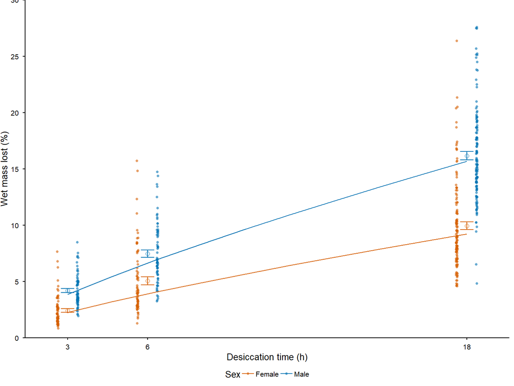

```r
mean_pc_loss <- water_data %>%
  group_by(Sex, Desiccation_time) %>%
  summarise(mean_pc = mean(Percent_change),
            se_pc = sd(Percent_change) / sqrt(n()),
            range = max(Percent_change) - min(Percent_change),
            n = n())

p_wetmass <- ggplot() +
  geom_point(data = water_data, aes(Desiccation_time, Percent_change, colour = Sex), alpha = 0.6, stroke = NA,
             position = position_jitterdodge(jitter.height = 0, jitter.width = 0.1, dodge = 1.5)) +
  geom_point(data = mean_pc_loss, aes(Desiccation_time, mean_pc, colour = Sex),
             size = 2, shape = 1,
             position = position_dodge(0), show.legend = FALSE) +
  geom_errorbar(data = mean_pc_loss, aes(Desiccation_time, colour = Sex,
                                         ymin = mean_pc - se_pc,
                                         ymax = mean_pc + se_pc),
                width = 1, linewidth = 0.5,
                position = position_dodge(0)) +
  geom_line(data = PC_fit, aes(Desiccation_time, fit, colour = Sex), linewidth = 0.5) +
  labs(y = "Wet mass lost (%)",
       x = "Desiccation time (h)") +
  scale_shape_manual(values = sex_point) +
  scale_colour_manual(values = sex_pal) +
  scale_y_continuous(limits = c(0, 30), breaks = seq(0, 35, 5), expand = expansion(mult = c(0, 0))) +
  scale_x_continuous(breaks = c(0, 3, 6, 18))

p_wetmass
```

```r
ggsave(p_wetmass,
       dpi = 300, width = single_width,
       units = "mm", height = single_width,
       filename = "data/Desiccation 2025/figures/wetmass_plot.png")
```

# 4 Water loss

- No interaction
- Keep same model structure as percentage change in mass

```r
WL_mod <- water_data %>%
  lmer(log(Relative_water_loss) ~ log(Desiccation_time) + Sex + (1|Experiment), ., REML = FALSE)

summary(WL_mod)
```

```
Linear mixed model fit by maximum likelihood . t-tests use Satterthwaite's
  method [lmerModLmerTest]
Formula: log(Relative_water_loss) ~ log(Desiccation_time) + Sex + (1 |
    Experiment)
   Data: .

      AIC       BIC    logLik -2*log(L)  df.resid
    442.4     463.9    -216.2     432.4       538

Scaled residuals:
    Min      1Q  Median      3Q     Max
-3.7172 -0.5790 -0.0673  0.6110  3.2420

Random effects:
 Groups     Name        Variance Std.Dev.
 Experiment (Intercept) 0.002334 0.04831
 Residual               0.128718 0.35877
Number of obs: 543, groups:  Experiment, 4

Fixed effects:
                       Estimate Std. Error        df t value
(Intercept)             0.37516    0.05520  45.57198   6.797
log(Desiccation_time)   0.76958    0.02031 542.23996  37.885
SexMale                 0.42102    0.03079 539.40793  13.672
                                  Pr(>|t|)
(Intercept)                   0.0000000192 ***
log(Desiccation_time) < 0.0000000000000002 ***
SexMale               < 0.0000000000000002 ***
---
Signif. codes:  0 '***' 0.001 '**' 0.01 '*' 0.05 '.' 0.1 ' ' 1

Correlation of Fixed Effects:
            (Intr) lg(D_)
lg(Dscctn_) -0.797
SexMale     -0.270 -0.010
```

```r
WL_mod_linear <- water_data %>%
  lmer(Relative_water_loss ~ Desiccation_time + Sex + (1|Experiment), ., REML = FALSE)
anova(WL_mod, WL_mod_linear)
```

```
Data: .
Models:
WL_mod: log(Relative_water_loss) ~ log(Desiccation_time) + Sex + (1 | Experiment)
WL_mod_linear: Relative_water_loss ~ Desiccation_time + Sex + (1 | Experiment)
              npar     AIC     BIC  logLik -2*log(L) Chisq Df Pr(>Chisq)
WL_mod           5  442.39  463.88  -216.2    432.39
WL_mod_linear    5 3126.05 3147.53 -1558.0   3116.05     0  0
```

```r
WL_fit <- tibble(Desiccation_time = rep(seq(3, 18, length.out = 10), 2),
                  Sex = c(rep("Female", 10), rep("Male", 10))) %>%
  mutate(fit = exp(predict(WL_mod, newdata = ., re.form = NA)))
```

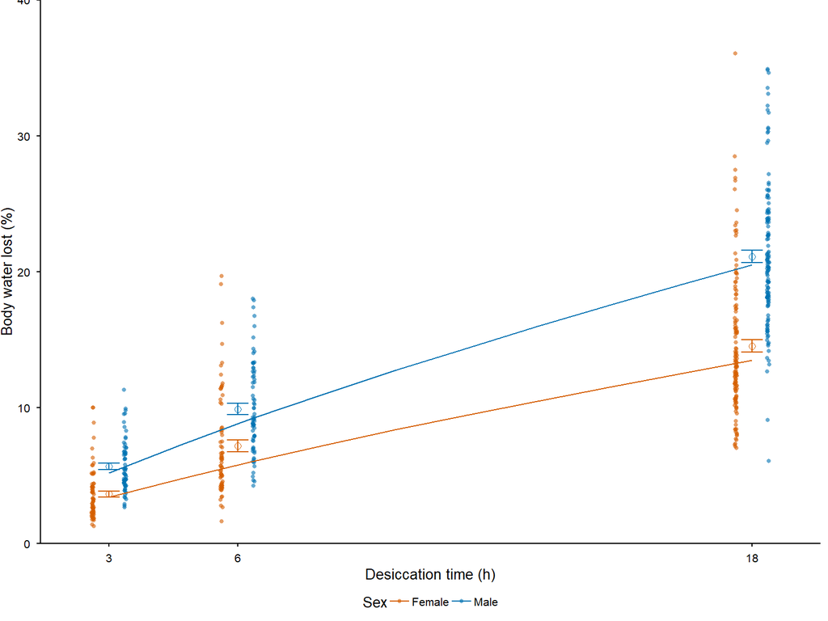

```r
mean_water_loss <- water_data %>%
  group_by(Sex, Desiccation_time) %>%
  summarise(mean_wl = mean(Relative_water_loss),
            se_pc = sd(Relative_water_loss) / sqrt(n()),
            range = max(Relative_water_loss) - min(Relative_water_loss),
            n = n())

p_water_loss <- ggplot() +
  geom_point(data = water_data, aes(Desiccation_time, Relative_water_loss, colour = Sex), alpha = 0.6, stroke = NA,
             position = position_jitterdodge(jitter.height = 0, jitter.width = 0.1, dodge = 1.5)) +
  geom_point(data = mean_water_loss, aes(Desiccation_time, mean_wl, colour = Sex),
             size = 2, shape = 1,
             position = position_dodge(0), show.legend = FALSE) +
  geom_errorbar(data = mean_water_loss, aes(Desiccation_time, colour = Sex,
                                            ymin = mean_wl - se_pc,
                                            ymax = mean_wl + se_pc),
                width = 1, linewidth = 0.5,
                position = position_dodge(0)) +
  geom_line(data = WL_fit, aes(Desiccation_time, fit, colour = Sex), linewidth = 0.5) +
  labs(y = "Body water lost (%)",
       x = "Desiccation time (h)") +
  scale_shape_manual(values = sex_point) +
  scale_colour_manual(values = sex_pal) +
  scale_y_continuous(limits = c(0, 40), breaks = seq(0, 50, 10), expand = expansion(mult = c(0.0, 0))) +
  scale_x_continuous(breaks = c(0, 3, 6, 18))

p_water_loss
```

```r
ggsave(p_water_loss,
       dpi = 300, width = 160,
       units = "mm", height = 150,
       filename = "data/Desiccation 2025/figures/relativeWL_plot.png")
```

# 5 Water loss rate

- No interaction

```r
WLR_mod <- water_data %>%
  lmer(log(WLR) ~ log(Desiccation_time) + Sex + (1|Experiment), ., REML = FALSE)

summary(WLR_mod)
```

```
Linear mixed model fit by maximum likelihood . t-tests use Satterthwaite's
  method [lmerModLmerTest]
Formula: log(WLR) ~ log(Desiccation_time) + Sex + (1 | Experiment)
   Data: .

      AIC       BIC    logLik -2*log(L)  df.resid
    442.4     463.9    -216.2     432.4       538

Scaled residuals:
    Min      1Q  Median      3Q     Max
-3.7172 -0.5790 -0.0673  0.6110  3.2420

Random effects:
 Groups     Name        Variance Std.Dev.
 Experiment (Intercept) 0.002334 0.04831
 Residual               0.128718 0.35877
Number of obs: 543, groups:  Experiment, 4

Fixed effects:
                       Estimate Std. Error        df t value
(Intercept)             0.37516    0.05520  45.57199   6.797
log(Desiccation_time)  -0.23042    0.02031 542.23996 -11.344
SexMale                 0.42102    0.03079 539.40793  13.672
                                  Pr(>|t|)
(Intercept)                   0.0000000192 ***
log(Desiccation_time) < 0.0000000000000002 ***
SexMale               < 0.0000000000000002 ***
---
Signif. codes:  0 '***' 0.001 '**' 0.01 '*' 0.05 '.' 0.1 ' ' 1

Correlation of Fixed Effects:
            (Intr) lg(D_)
lg(Dscctn_) -0.797
SexMale     -0.270 -0.010
```

```r
WLR_mod_linear <- water_data %>%
  lmer(WLR ~ Desiccation_time + Sex + (1|Experiment), ., REML = FALSE)
anova(WLR_mod, WLR_mod_linear)
```

```
Data: .
Models:
WLR_mod: log(WLR) ~ log(Desiccation_time) + Sex + (1 | Experiment)
WLR_mod_linear: WLR ~ Desiccation_time + Sex + (1 | Experiment)
               npar    AIC    BIC  logLik -2*log(L) Chisq Df Pr(>Chisq)
WLR_mod           5 442.39 463.88 -216.20    432.39
WLR_mod_linear    5 763.06 784.55 -376.53    753.06     0  0
```

```r
WLR_fit <- tibble(Desiccation_time = rep(seq(3, 18, length.out = 10), 2),
                  Sex = c(rep("Female", 10), rep("Male", 10))) %>%
  mutate(fit = exp(predict(WLR_mod, newdata = ., re.form = NA)))
```

```r
# Water loss rate (relative water content)
mean_WLR <- water_data %>%
  group_by(Sex, Desiccation_time) %>%
  summarise(mean_WLR = mean(WLR),
            se_WLR = sd(WLR) / sqrt(n()),
            range = max(WLR) - min(WLR),
            n = n())

knitr::kable(mean_WLR, digits = 3)
```

| Sex | Desiccation_time | mean_WLR | se_WLR | range | n |
| --- | --- | --- | --- | --- | --- |
| Female | 3 | 1.208 | 0.074 | 2.911 | 71 |
| Female | 6 | 1.195 | 0.074 | 3.009 | 72 |
| Female | 18 | 0.806 | 0.025 | 1.615 | 130 |
| Male | 3 | 1.883 | 0.077 | 2.884 | 68 |
| Male | 6 | 1.647 | 0.067 | 2.290 | 71 |
| Male | 18 | 1.173 | 0.026 | 1.602 | 131 |

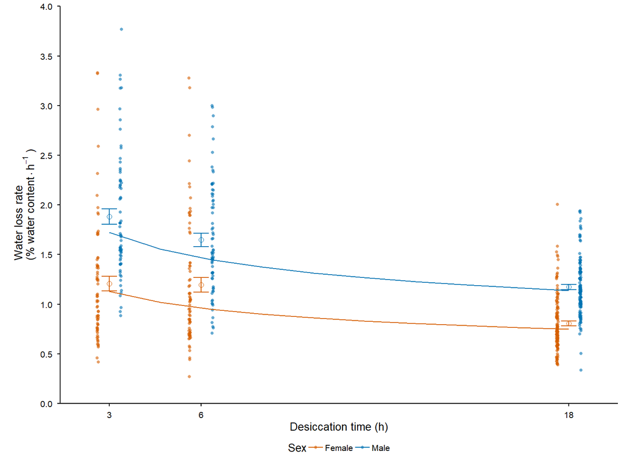

```r
p_WLR <- ggplot() +
  geom_point(data = water_data, aes(Desiccation_time, WLR, colour = Sex), alpha = 0.6, stroke = NA,
             position = position_jitterdodge(jitter.height = 0, jitter.width = 0.1, dodge = 1.5)) +
  geom_point(data = mean_WLR, aes(Desiccation_time, mean_WLR, colour = Sex),
             size = 2, shape = 1,
             position = position_dodge(0), show.legend = FALSE) +
  geom_errorbar(data = mean_WLR, aes(Desiccation_time, colour = Sex,
                                     ymin = mean_WLR - se_WLR,
                                     ymax = mean_WLR + se_WLR),
                width = 1, linewidth = 0.5,
                position = position_dodge(0)) +
  geom_line(data = WLR_fit, aes(Desiccation_time, fit, colour = Sex), linewidth = 0.5) +
  labs(y = expression("Water loss rate\n(% water content"%.%"h"^-1~")"),
       x = "Desiccation time (h)") +
  scale_shape_manual(values = sex_point) +
  scale_colour_manual(values = sex_pal) +
  scale_y_continuous(limits = c(0, 4), breaks = seq(0, 5, 0.5), expand = expansion(mult = c(0.0, 0))) +
  scale_x_continuous(breaks = c(3, 6, 18)) +
  theme(axis.title.y = element_text(hjust = 0.5), plot.margin = margin(t = 6, r = 5.5, b = 5.5, l = 20, unit = "pt"))

p_WLR
```

```r
ggsave(p_WLR,
       dpi = 300, width = single_width,
       units = "mm", height = single_width,
       filename = "data/Desiccation 2025/figures/WLR_plot.png")
```

# 6 Recovery

118 crickets: 58 females and 60 males

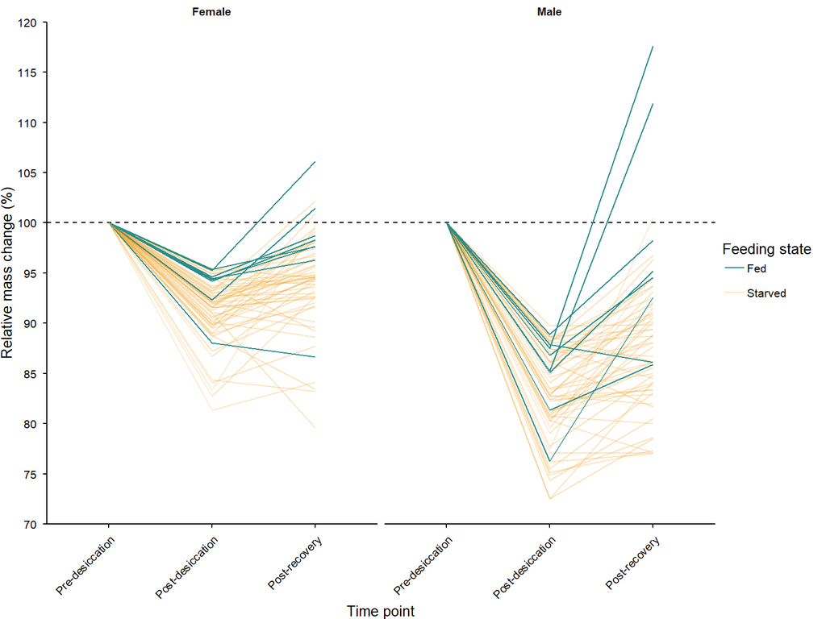

```r
all_rehydration <- bind_rows(rehydration_ions, rehydration_volume, rehydration_tissue, rehydration_guts)

all_rehydration$Cricket_ID = paste(all_rehydration$Cricket_ID, all_rehydration$Experiment, sep = "_")

rehydration_plot <- ggplot(all_rehydration, aes(Timepoint, Change, group = Cricket_ID, colour = Time_treatment, alpha = Time_treatment)) +
  geom_hline(yintercept = 100, linetype = 2) +
  geom_line(linewidth = 0.5) +
  theme(legend.position = "right") +
  ylab("Relative mass change (%)") +
  scale_y_continuous(breaks = seq(0, 120, 5), limits = c(70, 120), expand = c(0, 0)) +
  scale_x_discrete(name = "Time point", labels = c("Pre-desiccation", "Post-desiccation", "Post-recovery")) +
  facet_grid(~Sex) +
  theme(legend.position = "right",
        legend.title.position = "top",
        axis.text.x = element_text(angle = 45, hjust = 1)) +
  scale_alpha_manual(name = "Feeding state", values = c(1, 0.3), label = c("Fed", "Starved")) +
  scale_color_manual(name = "Feeding state", values = c("#298c8c", "#f1a226"), label = c("Fed", "Starved"))

rehydration_plot
```

```r
all_rehydration %>%
  group_by(Timepoint, Sex) %>%
  summarise(mean = mean(Change),
            n = n(),
            se = sd(Change)/sqrt(n))
```

```
# A tibble: 6 × 5
# Groups:   Timepoint [3]
  Timepoint               Sex         mean     n        se
  <fct>                   <chr>      <dbl> <int>     <dbl>
1 Start_Percent           Female 100          58 0
2 Start_Percent           Male   100          60 0
3 Percent_change          Female  91.22901    58 0.4342408
4 Percent_change          Male    82.87638    60 0.5882526
5 Percent_change_recovery Female  94.35723    58 0.6354097
6 Percent_change_recovery Male    88.60406    60 0.9656841
```

```r
ggsave(rehydration_plot,
       dpi = 300, width = double_width,
       units = "mm", height = single_height,
       filename = "data/Desiccation 2025/figures/rehydration.png")
```

## 6.1 Recovery stats

```r
rm_mod <- lme4::lmer(Change ~ Timepoint + (1|Cricket_ID) + (1|Experiment), all_rehydration, REML = FALSE)
library(lmerTest)
summary(rm_mod)
```

```
Linear mixed model fit by maximum likelihood  ['lmerMod']
Formula: Change ~ Timepoint + (1 | Cricket_ID) + (1 | Experiment)
   Data: all_rehydration

      AIC       BIC    logLik -2*log(L)  df.resid
   2154.3    2177.6   -1071.2    2142.3       348

Scaled residuals:
    Min      1Q  Median      3Q     Max
-2.4219 -0.5163  0.0473  0.5633  4.8649

Random effects:
 Groups     Name        Variance Std.Dev.
 Cricket_ID (Intercept)  7.7671  2.7869
 Experiment (Intercept)  0.1099  0.3314
 Residual               19.0093  4.3600
Number of obs: 354, groups:  Cricket_ID, 118; Experiment, 4

Fixed effects:
                                 Estimate Std. Error t value
(Intercept)                       99.9980     0.5061  197.58
TimepointPercent_change          -13.0181     0.5676  -22.93
TimepointPercent_change_recovery  -8.5681     0.5676  -15.10

Correlation of Fixed Effects:
            (Intr) TmpnP_
TmpntPrcnt_ -0.561
TmpntPrcn__ -0.561  0.500
```

```r
anova(rm_mod)
```

```
Analysis of Variance Table
          npar Sum Sq Mean Sq F value
Timepoint    2  10332  5166.1  271.77
```

```r
emmeans::emmeans(rm_mod,  list(pairwise ~ Timepoint), adjust = "tukey")
```

```
$`emmeans of Timepoint`
 Timepoint               emmean    SE   df lower.CL upper.CL
 Start_Percent            100.0 0.559 14.4     98.8    101.2
 Percent_change            87.0 0.559 14.4     85.8     88.2
 Percent_change_recovery   91.4 0.559 14.4     90.2     92.6

Degrees-of-freedom method: kenward-roger
Confidence level used: 0.95

$`pairwise differences of Timepoint`
 1                                        estimate   SE  df t.ratio p.value
 Start_Percent - Percent_change              13.02 0.57 238  22.837 <0.0001
 Start_Percent - Percent_change_recovery      8.57 0.57 238  15.031 <0.0001
 Percent_change - Percent_change_recovery    -4.45 0.57 238  -7.806 <0.0001

Degrees-of-freedom method: kenward-roger
P value adjustment: tukey method for comparing a family of 3 estimates
```

# 7 Publication figure

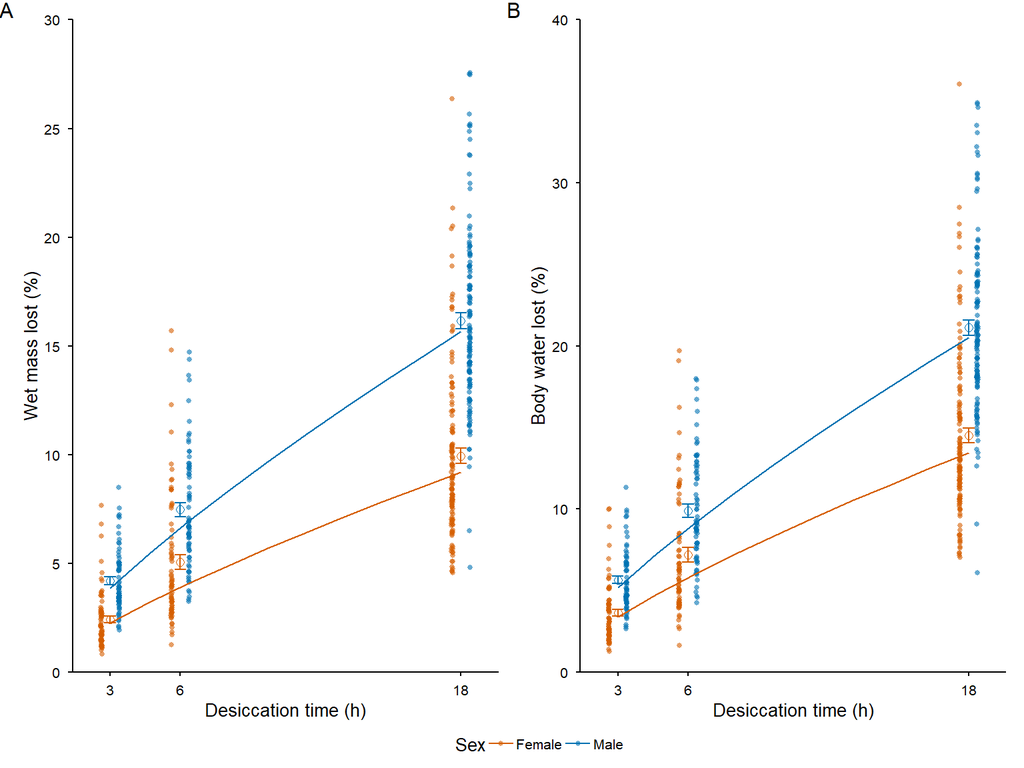

```r
Fig1 <- p_wetmass + p_water_loss +
  plot_layout(axis_titles = "collect" , guides = "collect") &
  plot_annotation(tag_levels = 'A')

Fig1_alt <- p_wetmass + p_WLR +
  plot_layout(axis_titles = "collect" , guides = "collect") &
  plot_annotation(tag_levels = 'A')

Fig1
```

```r
ggsave(Fig1,
       dpi = 300, width = double_width,
       units = "mm", height = single_height,
       filename = "data/Desiccation 2025/figures/Fig1WLR.png")
```